# DSO 522: In-Class Workbook 13

Matteo Sesia

November 19, 2024

# Instructions

Your task is to edit this R Markdown notebook to include your solutions, ensuring that it is well-organized and professional in appearance. Answers must be clear and concise. Start by downloading the Rmd file.

**Collaboration Policy.** You are allowed to discuss this workbook with your classmates and work in groups. Despite group discussions, each student must write and submit their own solutions.

**Assistance Policy.** You may ask for clarifications from the instructor and teaching assistant in class. Do not seek help on these workbooks outside of class, as they are intended to be completed during class time.

**Submission Requirements.** Solutions must be submitted on Brightspace as a PDF writeup. Use the ‘Knit to PDF’ feature in RStudio to prepare your PDF document. Ensure that your PDF document looks like the provided PDF version of the workbook, including all code used to obtain the results in proper code blocks. Make sure your PDF writeup includes *your name* in the title (replace my name with yours).

**Grading Criteria.** This workbook is worth 10 points. To achieve a grade of 10, your writeup must correctly answer all questions, be easy to understand, and be formatted correctly.

**Work Timeline.** You are expected to work on this assignment in class, but you may complete it at home within 24 hours. It is due on November 20, 2024, at 9:30 pm. Late submissions will incur a 50% deduction for any initial delay below 24 hours, and an additional 10% deduction for each additional day.

Remember, you will need to use the `fpp3` package to complete this assignment, as shown in the lecture.

```r
suppressMessages(library(fpp3))
```

# Problem 1

The us_gasoline series consists of weekly data for supplies of US finished motor gasoline product, from 2 February 1991 to 20 January 2017. The units are in “million barrels per day”. Consider only the data to the end of 2004.

```r
gas <- us_gasoline |> filter(year(Week) <= 2004)
```

1. Fit a harmonic regression with trend to the data. Experiment with changing the number Fourier terms. Select the appropriate number of Fourier terms to include by minimising the AICc or CV value. Plot the observed gasoline and fitted values and comment on what you see.
2. Plot the residuals of the final model using the `gg_tsresiduals()` function and comment on these.
3. Generate forecasts for the next year of data and plot these along with the actual data for 2005. Comment on the forecasts.
4. Fit a dynamic harmonic regression model to these data. How does it compare to the regression model you fitted in part (a)?
5. Check the residuals from both models and comment on what you see.

# Problem 1 Solutions

1. Fit a harmonic regression with trend to the data. Experiment with changing the number Fourier terms. Select the appropriate number of Fourier terms to include by minimising the AICc or CV value. Plot the observed gasoline and fitted values and comment on what you see.

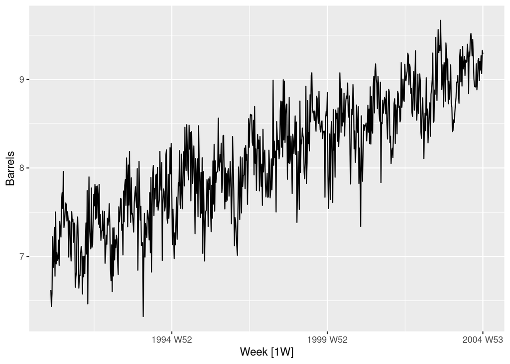

```r
gas <- us_gasoline |> filter(year(Week) <= 2004)
gas |> autoplot(Barrels)
```

```r
fit <- gas |>
  model(
    fourier1 = TSLM(Barrels ~ trend() + fourier(K = 1)),
    fourier2 = TSLM(Barrels ~ trend() + fourier(K = 2)),
    fourier3 = TSLM(Barrels ~ trend() + fourier(K = 3)),
    fourier4 = TSLM(Barrels ~ trend() + fourier(K = 4)),
    fourier5 = TSLM(Barrels ~ trend() + fourier(K = 5)),
    fourier6 = TSLM(Barrels ~ trend() + fourier(K = 6)),
    fourier7 = TSLM(Barrels ~ trend() + fourier(K = 7)),
    fourier8 = TSLM(Barrels ~ trend() + fourier(K = 8)),
    fourier9 = TSLM(Barrels ~ trend() + fourier(K = 9)),
    fourier10 = TSLM(Barrels ~ trend() + fourier(K = 10)),
    fourier11 = TSLM(Barrels ~ trend() + fourier(K = 11)),
    fourier12 = TSLM(Barrels ~ trend() + fourier(K = 12)),
    fourier13 = TSLM(Barrels ~ trend() + fourier(K = 13)),
    fourier14 = TSLM(Barrels ~ trend() + fourier(K = 14)),
    fourier15 = TSLM(Barrels ~ trend() + fourier(K = 15))
  )

glance(fit) |>
  arrange(AICc) |>
  select(.model, AICc, CV)
```

| .model | AICc | CV |
| --- | --- | --- |
| fourier7 | -1887.354 | 0.07401329 |
| fourier11 | -1884.716 | 0.07422777 |
| fourier8 | -1884.573 | 0.07428560 |
| fourier12 | -1884.433 | 0.07424048 |
| fourier6 | -1883.542 | 0.07441244 |
| fourier9 | -1881.947 | 0.07454120 |
| fourier10 | -1881.415 | 0.07458137 |
| fourier13 | -1881.347 | 0.07453760 |
| fourier14 | -1878.761 | 0.07478351 |
| fourier15 | -1875.995 | 0.07504818 |

[output cut: 5 more lines]

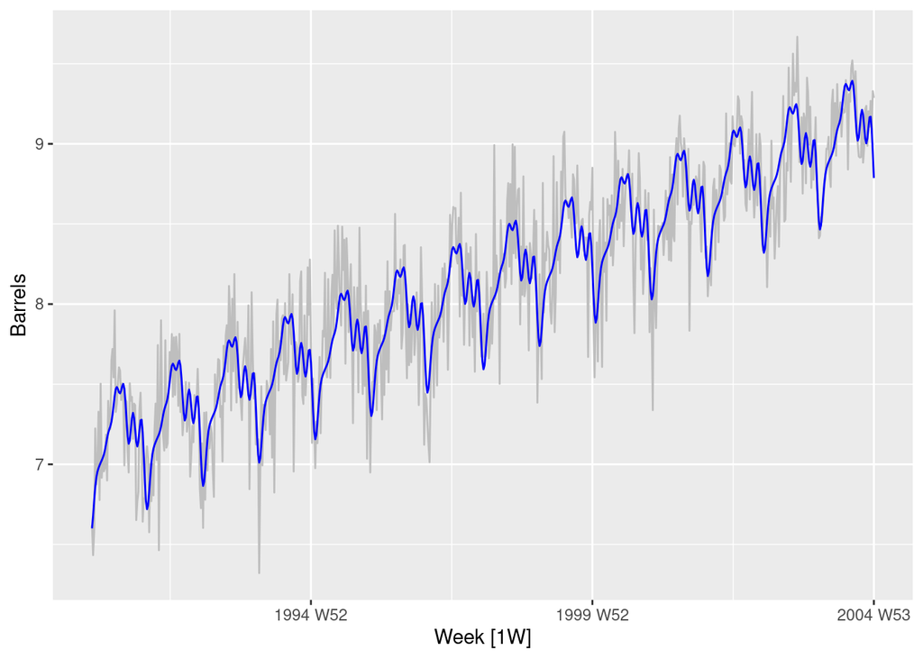

```r
# Best model has order 7
gas |>
  autoplot(Barrels, col = "gray") +
  geom_line(
    data = augment(fit) |> filter(.model == "fourier7"),
    aes(y = .fitted), col = "blue"
  )
```

This seems to have captured the annual seasonality quite well.

2. Plot the residuals of the final model using the `gg_tsresiduals()` function and comment on these.

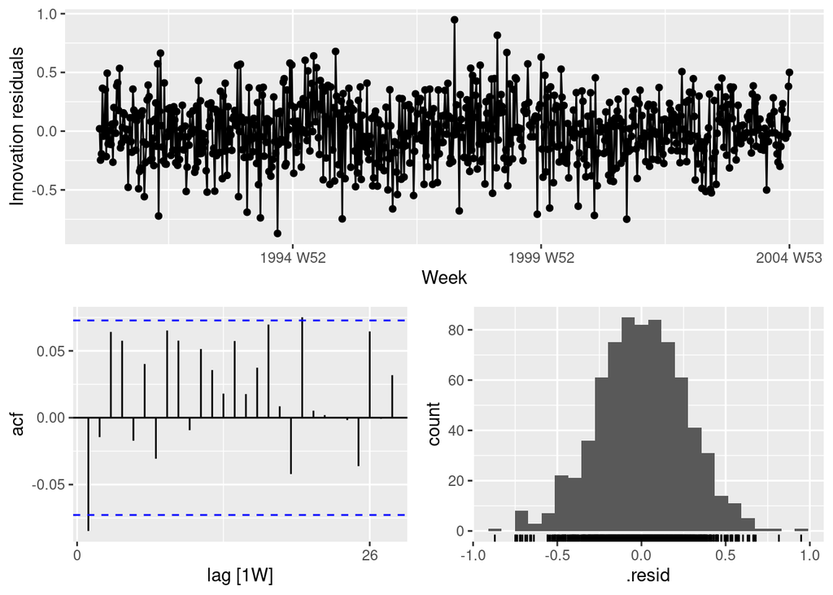

```r
fit |>
  select(fourier7) |>
  gg_tsresiduals()
```

The correlations are very small.

4. Generate forecasts for the next year of data and plot these along with the actual data for 2005. Comment on the forecasts.

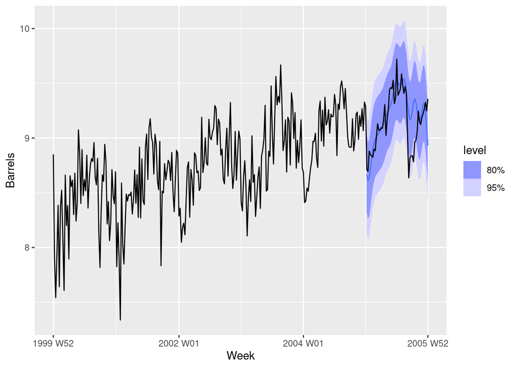

```r
fit |>
  select("fourier7") |>
  forecast(h = "1 year") |>
  autoplot(filter_index(us_gasoline, "2000" ~ "2006"))
```

The forecasts fit pretty well for the first six months, but not so well after that.

4. Fit a dynamic harmonic regression model to these data. How does it compare to the regression model you fitted in part (a)?

```r
fit <- gas |>
  model(
    fourier7 = TSLM(Barrels ~ trend() + fourier(K = 7)),
    dhm = ARIMA(Barrels ~ trend() + fourier(K=7) + PDQ(0,0,0))
  )
fit
```

| fourier7 | dhm |
| --- | --- |

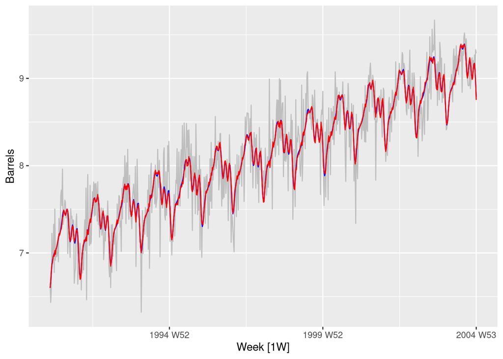

```r
gas |>
  autoplot(Barrels, col = "gray") +
  geom_line(
    data = augment(fit) |> filter(.model == "fourier7"),
    aes(y = .fitted), col = "blue"
  ) +
  geom_line(
    data = augment(fit) |> filter(.model == "dhm"),
    aes(y = .fitted), col = "red"
  )
```

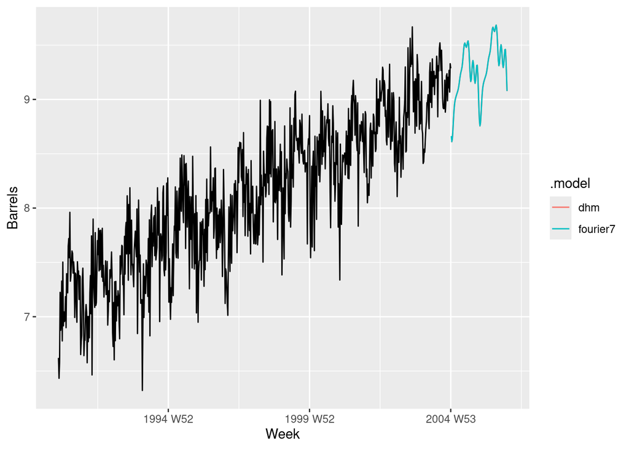

```r
fit |>
  forecast(h="2 years") |>
  autoplot(gas, level=NULL)
```

These two models are almost identical. The additional MA(1) parameter in the DHM only affects the first point forecast, and leads to slightly narrower the prediction intervals.

5. Check the residuals from both models and comment on what you see.

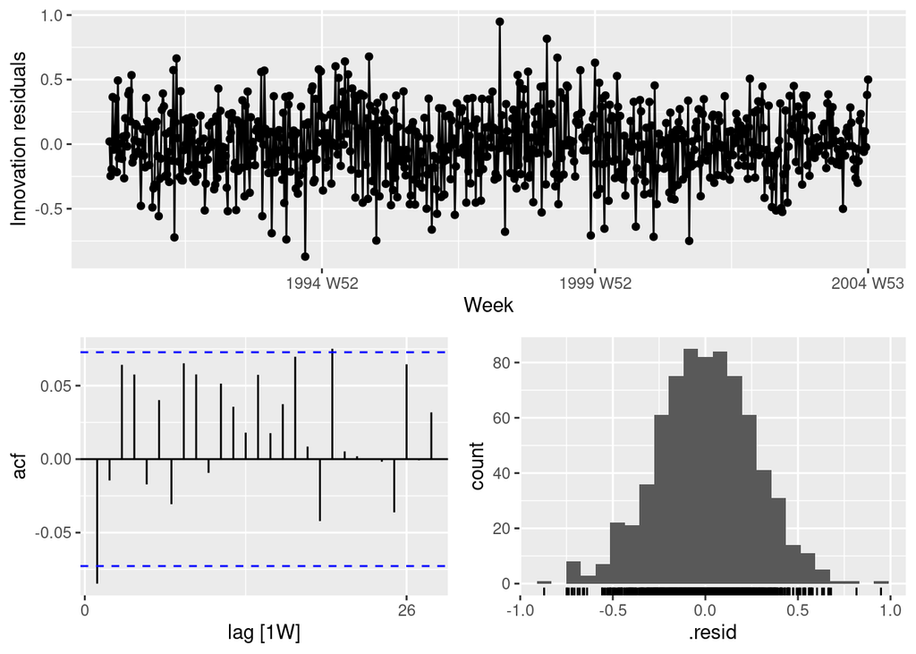

```r
fit |>
  select(fourier7) |>
  gg_tsresiduals()
```

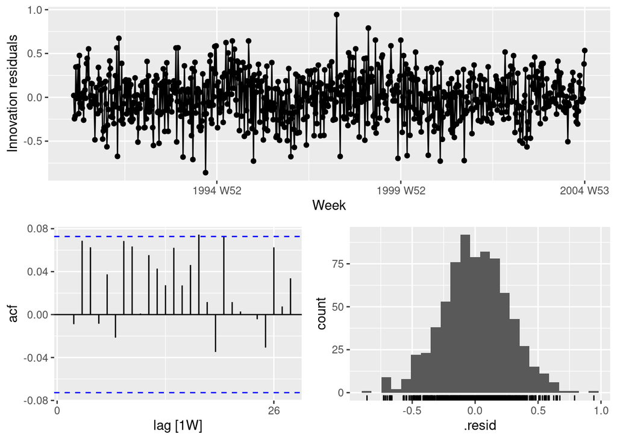

```r
fit |>
  select(dhm) |>
  gg_tsresiduals()
```

The tiny spike at lag 1 in the ACF of the regression model is corrected in the DHM model.

# Problem 2

Experiment with using `NNETAR()` on the following retail data. Compare its performance to that of ETS and ARIMA models. Use the data from 2018 for testing.

```r
retail <- aus_retail |>
  filter(`Series ID` == "A3349849A", year(Month) < 2018)
```

# Problem 2

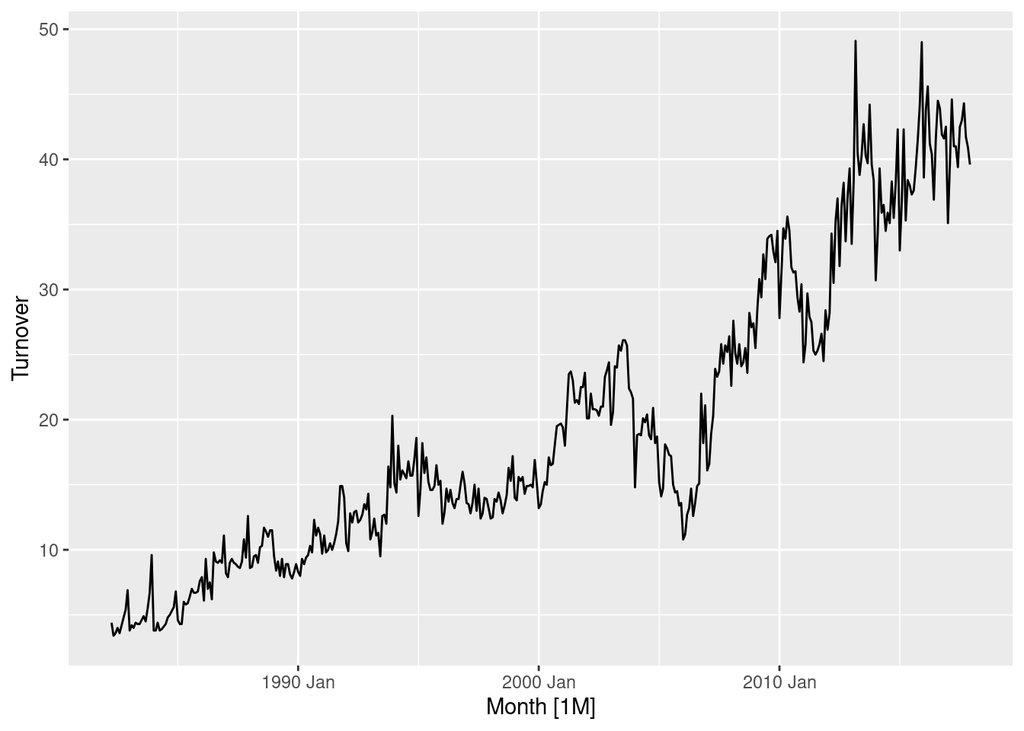

```r
retail |> autoplot(Turnover)
```

```r
fit <- retail |>
  model(
    ets = ETS(Turnover),
    arima = ARIMA(log(Turnover)),
    nnetar = NNETAR(log(Turnover))
  )
```

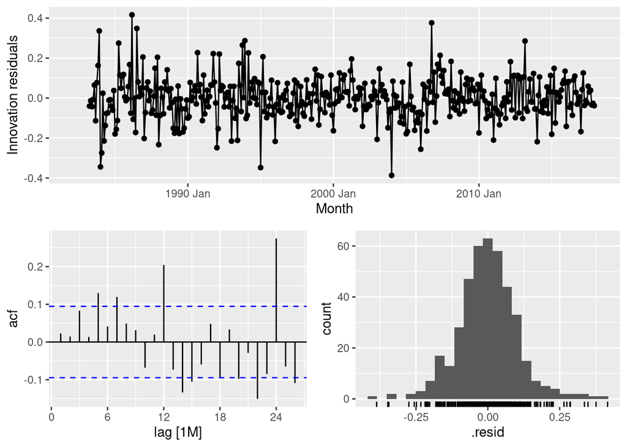

```r
fit |> select(nnetar) |> gg_tsresiduals()
```

The residuals from the NNETAR model have a lot of autocorrelations remaining.

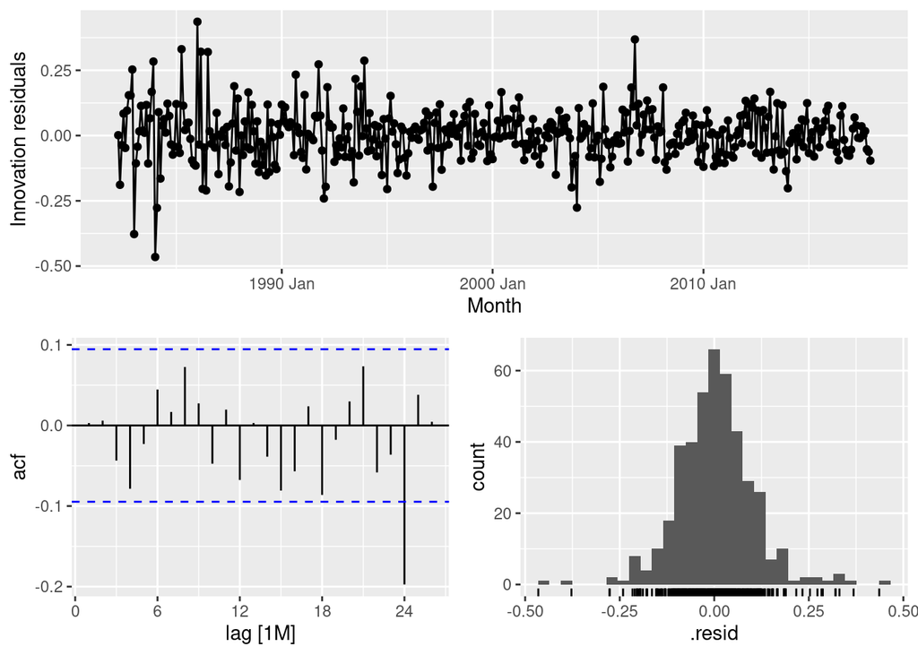

```r
fit |> select(arima) |> gg_tsresiduals()
```

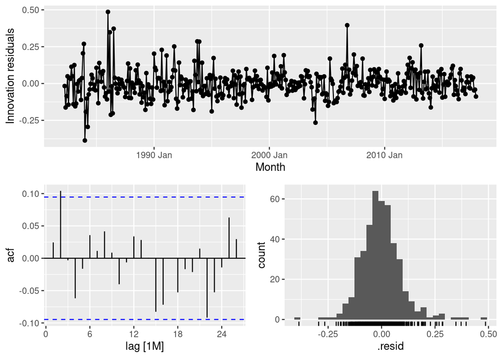

```r
fit |> select(ets) |> gg_tsresiduals()
```

The residuals from the ETS and ARIMA models have much less autocorrelation.

Let’s compare the prediction accuracy now.

```r
fit |>
  forecast(h = "3 years", times=1) |>
  accuracy(aus_retail) |>
  select(.model, RMSE, MAE, MAPE)
```

| .model | RMSE | MAE | MAPE |
| --- | --- | --- | --- |
| arima | 2.800502 | 2.500117 | 6.039458 |
| ets | 1.836738 | 1.586583 | 3.889782 |
| nnetar | 7.424703 | 6.752621 | 16.400343 |

The NNETAR model provides much worse forecasts than the other models.